# Career Beginnings of U.S. Returned Students (1917)

Cécile Armand

2026-05-03

Abstract

This document analyzes the career beginnings of US-educated Chinese using data from the *Who’s Who of American returned students* (Tsing Hua, 1917).

```r
# Load required packages

library(tidyverse)
library(FactoMineR)
library(Factoshiny)
```

# Data preparation

## Positions

```r
# Load dataset of positions after return

head(career_post)
```

[output not shown]

```r
# Select first position held by individuals
career_start <- career_post %>% filter(step == "1") # 358 first positions

head(career_start)
```

```
## # A tibble: 6 × 18
##   DocId  phase  year year_src_corr year_src_raw month   end  step position level
##   <chr>  <chr> <dbl>         <dbl>        <dbl> <dbl> <dbl> <dbl> <chr>    <chr>
## 1 imh-1… POST…  1914          1914         1914    NA  1917     1 English… Mid-…
## 2 imh-1… POST…  1907          1907         1907    NA    NA     1 Vice-Co… Exec…
## 3 imh-1… POST…  1915          1915         1915    NA    NA     1 Third S… Mid-…
## 4 imh-1… POST…  1912          1912         1912    NA  1916     1 Exchang… Mid-…
## 5 imh-1… POST…  1915          1915         1915    NA    NA     1 Teacher  Mid-…
## 6 imh-1… POST…  1902          1902         1902    NA  1910     1 Residen… Mid-…
## # ℹ 8 more variables: level_code <chr>, Institution <chr>, sublevel <chr>,
## #   sector <chr>, sector_code <chr>, city <chr>, province <chr>, area <chr>
```

## Supplementary data

```r
# birth/attributes
head(main_data_all)
```

```
## # A tibble: 6 × 38
##   DocId   page name_source FullName_zh FullName_py FullName_wg gender birth_year
##   <chr>  <dbl> <chr>       <chr>       <chr>       <chr>       <chr>       <dbl>
## 1 imh-1…    10 胡其炳      胡其炳      Hu Qibing   Hu C. P.    Male         1872
## 2 imh-1…    19 施肇基      施肇基      Shi Zhaoji  Sze Sao-Ke… Male         1876
## 3 imh-1…    24 徐良        徐良        Xu Liang    Chui Leong  Male         1892
## 4 imh-1…    28 徐崇欽      徐崇欽      Xu Chongqin Zee C. J    Male         1878
## 5 imh-1…    29 徐可陞      徐可陞      Xu Kesheng  Zee Ko-Seng Male         1884
## 6 imh-1…    34 夏元瑮      夏元瑮      Jia Yuanli  Hsia Yuan-… Male         1884
## # ℹ 30 more variables: age_in_1917 <dbl>, Birth_Province_zh <chr>,
## #   Birth_Province_eng_standard <chr>, Birth_location_zh <chr>,
## #   Birth_Location_eng_standard <chr>, ancestry_province <chr>,
## #   ancestry_locality <chr>, married <chr>, married_year <dbl>,
## #   marriage_age <dbl>, sons <dbl>, daugthers <dbl>, total_children <dbl>,
## #   Funding <chr>, arrived_year <dbl>, arrived_month <chr>,
## #   estimated_arrived_year <dbl>, period <chr>, arrived_cohort <chr>, …
```

```r
# Education in China (366 curricula)

head(edu_china)
```

```
## # A tibble: 6 × 5
##   DocId      name   Institution                  Location   Province
##   <chr>      <chr>  <chr>                        <chr>      <chr>
## 1 imh-11-101 周典   Peking Government University Beijing    Hebei
## 2 imh-11-101 周典   Victoria University          Manchester England
## 3 imh-11-102 周宗華 Peiyang University           Tianjin    Hebei
## 4 imh-11-104 周象賢 Nanyang College              Shanghai   Jiangsu
## 5 imh-11-105 卓康成 Honolulu High School         Honolulu   Hawaii
## 6 imh-11-106 卓鏞詩 St. John's University        Shanghai   Jiangsu
```

```r
# Education in USA (810 curricula)

head(edu_us)
```

```
## # A tibble: 6 × 6
##   DocId      name   Organization               Position category   category_main
##   <chr>      <chr>  <chr>                      <chr>    <chr>      <chr>
## 1 imh-11-0   丁崇吉 Harvard University         US       education… education
## 2 imh-11-1   刁慶湘 University of Pennsylvania US       education… education
## 3 imh-11-10  王寵惠 Yale University            US       education… education
## 4 imh-11-100 周倫元 Lehigh University          US       education… education
## 5 imh-11-101 周典   University of Pennsylvania US       education… education
## 6 imh-11-102 周宗華 Brown University           US       education… education
```

```r
# Work experience in China (PRE-US) (151 positions)

head(position_eng_pre_us)
```

```
## # A tibble: 6 × 17
##   DocId      name_eng    situation prefix post_detail Institution sublevel city
##   <chr>      <chr>       <chr>     <chr>  <chr>       <chr>       <chr>    <chr>
## 1 imh-11-366 Kuang, Yin… PRE-US    <NA>   Academician Hanlin Aca… <NA>     Beij…
## 2 imh-11-6   Wang, Chen… PRE-US    <NA>   Academician Hanlin Aca… <NA>     Beij…
## 3 imh-11-100 Chow, Lun-… PRE-US    <NA>   Agent       Standard O… <NA>     Shan…
## 4 imh-11-26  Cheng, Gun… PRE-US    Assis… Assistant … Yang Tse K… <NA>     Nanj…
## 5 imh-11-263 Loh, Tachu… PRE-US    Assis… Assistant … Commercial… <NA>     Shan…
## 6 imh-11-56  Lee, Beiya… PRE-US    <NA>   Assistant … Canton-Han… <NA>     Guan…
## # ℹ 9 more variables: province <chr>, Hypoth_year <dbl>, StartYear <dbl>,
## #   Start_Month <lgl>, EndYear <dbl>, post_no <dbl>, Exam <lgl>,
## #   post_full <chr>, post <chr>
```

```r
# Work experience in the US (134 positions)

head(position_eng_us)
```

```
## # A tibble: 6 × 17
##   DocId      name_eng    situation prefix post_detail Institution sublevel city
##   <chr>      <chr>       <chr>     <chr>  <chr>       <chr>       <chr>    <chr>
## 1 imh-11-94  Chow, H. K  US        <NA>   Aeronautic… Curtiss Ae… <NA>     <NA>
## 2 imh-11-239 Franking, … US        <NA>   Agent       Review of … <NA>     New …
## 3 imh-11-239 Franking, … US        <NA>   Assistant   Wilbur Mer… <NA>     Detr…
## 4 imh-11-290 Hou, Moo-C… US        Assis… Assistant   New York S… <NA>     New …
## 5 imh-11-210 Ts'en, Mon… US        Assis… Assistant   New York E… Chief E… New …
## 6 imh-11-210 Ts'en, Mon… US        Assis… Assistant   Union Coll… Electri… <NA>
## # ℹ 9 more variables: province <chr>, Hypoth_year <dbl>, StartYear <dbl>,
## #   Start_Month <chr>, EndYear <dbl>, post_no <dbl>, Exam <lgl>,
## #   post_full <chr>, post <chr>
```

# Basic Analysis

## Position level

```r
career_start %>% group_by(level) %>% count() %>%
  mutate(percent = round(n/358*100, 2)) %>%
  arrange(desc(n))
```

```
## # A tibble: 7 × 3
## # Groups:   level [7]
##   level             n percent
##   <chr>         <int>   <dbl>
## 1 Mid-level       217   60.6
## 2 Senior           48   13.4
## 3 Junior           47   13.1
## 4 Executive        34    9.5
## 5 Top Executive     6    1.68
## 6 Student           5    1.4
## 7 Other             1    0.28
```

## Sector of employment

```r
career_start %>% group_by(sector_code) %>%count() %>%
  mutate(percent = round(n/358*100, 2)) %>%
  arrange(desc(n))
```

```
## # A tibble: 10 × 3
## # Groups:   sector_code [10]
##    sector_code     n percent
##    <chr>       <int>   <dbl>
##  1 EDU           148   41.3
##  2 GOVC           48   13.4
##  3 RAIL           32    8.94
##  4 PRIV           30    8.38
##  5 OTHER          27    7.54
##  6 ENG            22    6.15
##  7 ADML           17    4.75
##  8 ADMC           13    3.63
##  9 BANK           13    3.63
## 10 GOVL            8    2.23
```

## Place of employment

```r
career_start %>% group_by(area) %>% count() %>%
  mutate(percent = round(n/358*100, 2)) %>%
  arrange(desc(n))
```

```
## # A tibble: 6 × 3
## # Groups:   area [6]
##   area                n percent
##   <chr>           <int>   <dbl>
## 1 Beijing_Tianjin   136   38.0
## 2 Shanghai           58   16.2
## 3 Jiangnan           57   15.9
## 4 Other_China        56   15.6
## 5 Guangdong          40   11.2
## 6 Abroad             11    3.07
```

# Multivariate analysis

```r
# Select relevant data (birth place, return year, source of funding, discipline)
meta_all <- main_data_all %>% select(DocId, Birth_Province_eng_standard, estimated_returned_year, Funding, field2_code)

# Recode disciplines
meta_all <-  main_data_all %>%
  mutate(Discipline = fct_collapse(field2_code,
                                   "Social Sciences" = c("SOC"),
                                   "Humanities" = c("HUM"),
                                   "Multiple" = c("MULTI"),
                                   "Sciences" = c("NAT", "SCI"),
                                   "Other" = c("MIL", "PROF"),
                                   "Engineering" = c("ENG")))

meta_all$Discipline <- replace(meta_all$Discipline, is.na(meta_all$Discipline), "Other")

# Recode places of birth

meta_all <- meta_all  %>%
  mutate(Nativeplace = fct_collapse(Birth_Province_eng_standard,
                                    "Jiangsu" = c("Jiangsu"),
                                    "Guangdong" = c("Guangdong"),
                                    "Zhejiang" = c("Zhejiang"),
                                    "Hebei-Zhili" = c("Hebei", "Zhili"),
                                    "Fujian" = c("Fujian"),
                                    "Hubei" = c("Hubei"),
                                    "Jiangxi" = c("Jiangxi"),
                                    "Other" = c("Anhui", "Sichuan", "Shandong", "Henan", "Hunan", "Gansu", "Guangxi", "Guizhou"),
                                    "Overseas" = c("Hawaii", "California", "Hongkong", "Malaysia", "New York")))

meta_all$Nativeplace <- replace(meta_all$Nativeplace, is.na(meta_all$Nativeplace), "Other")

# Recode generational cohorts

## Periodization 1 : Pre/Post Boxer
meta_all$Generation <- cut(meta_all$estimated_returned_year,
                       breaks = c(0, 1911, 1917),  # Define breakpoints
                       labels = c("PreBoxer", "PostBoxer"),  # Assign labels
                       right = FALSE)


meta_all$Generation <- replace(meta_all$Generation, is.na(meta_all$Generation), "PreBoxer")

## Pre/Post Examination/Revolution
meta_all$returned_period <- cut(meta_all$estimated_returned_year,
                       breaks = c(0, 1906, 1912, 1917),  # Define breakpoints
                       labels = c("Pionneer", "PostExam", "PostRevolution"),  # Assign labels
                       right = FALSE)

meta_all$returned_period <- replace(meta_all$returned_period, is.na(meta_all$returned_period), "PostExam")

meta_all %>% group_by(returned_period) %>% count(sort = TRUE)
```

[output not shown]

Comment on the periodization method. To categorize the student population by generation and cohort based on their year of return, we employ two distinct periodizations. The first is based on Sino–U.S. relations and funding policies, particularly the U.S. remission of the Boxer Indemnity in 1908. We assume that recipients of Boxer Indemnity scholarships returned during the early Republican period, on the premise that their studies required a minimum duration of three years. The second periodization focuses on China’s internal political context, including the reform of the elite selection system marked by the abolition of the imperial examination in 1905, as well as the Xinhai Revolution and the founding of the Republic in 1912.

```r
meta_all %>% group_by(Nativeplace) %>% count(sort = TRUE)
```

```
## # A tibble: 9 × 2
## # Groups:   Nativeplace [9]
##   Nativeplace     n
##   <fct>       <int>
## 1 Jiangsu       137
## 2 Guangdong     102
## 3 Zhejiang       39
## 4 Hebei-Zhili    30
## 5 Other          28
## 6 Overseas       21
## 7 Fujian         17
## 8 Hubei          17
## 9 Jiangxi        10
```

```r
meta_all %>% group_by(Discipline) %>% count(sort = TRUE)
```

```
## # A tibble: 6 × 2
## # Groups:   Discipline [6]
##   Discipline          n
##   <fct>           <int>
## 1 Social Sciences   137
## 2 Engineering       112
## 3 Sciences           47
## 4 Multiple           38
## 5 Other              35
## 6 Humanities         32
```

```r
meta_all %>% group_by(Generation) %>% count(sort = TRUE)
```

```
## # A tibble: 2 × 2
## # Groups:   Generation [2]
##   Generation     n
##   <fct>      <int>
## 1 PostBoxer    301
## 2 PreBoxer     100
```

```r
meta_all %>% group_by(returned_period) %>% count(sort = TRUE)
```

```
## # A tibble: 3 × 2
## # Groups:   returned_period [3]
##   returned_period     n
##   <fct>           <int>
## 1 PostRevolution    260
## 2 PostExam          112
## 3 Pionneer           29
```

```r
# select recoded data

meta_all <- meta_all %>% select(DocId, Generation, returned_period, Nativeplace, Funding, Discipline)

# join with career data

career_start_meta <- inner_join(meta_all, career_start)
```

## Level

```r
start_level_cohort_count <- career_start_meta %>% group_by(returned_period, level_code) %>% count()
start_level_cohort_count <- start_level_cohort_count %>% rename(nlevel = n)
start_level_cohort_count <- left_join(start_level_cohort_count, period_count)
start_level_cohort_count <- start_level_cohort_count %>% mutate(percent = round(nlevel/n*100, 0))
```

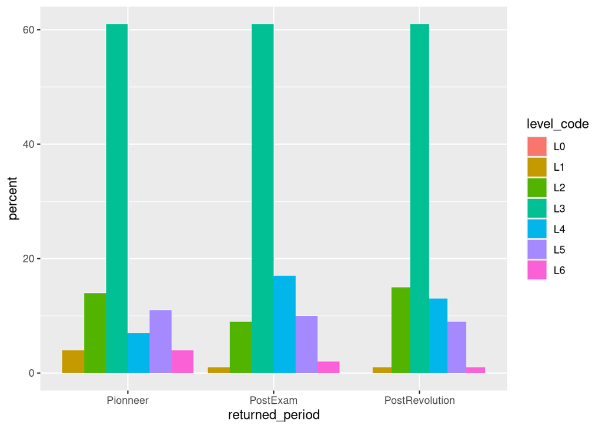

```r
ggplot(start_level_cohort_count, aes(fill=level_code, y=percent, x=returned_period)) +
  geom_bar(position="dodge", stat="identity")
```

## Sector over time

```r
# Sector by period
start_sector_cohort_count <- career_start_meta %>% group_by(returned_period, sector_code) %>% count()
start_sector_cohort_count <- start_sector_cohort_count %>% rename(nsector = n)
start_sector_cohort_count <- left_join(start_sector_cohort_count, period_count)
start_sector_cohort_count <- start_sector_cohort_count %>% mutate(percent = round(nsector/n*100, 0)) %>% drop_na(returned_period)
```

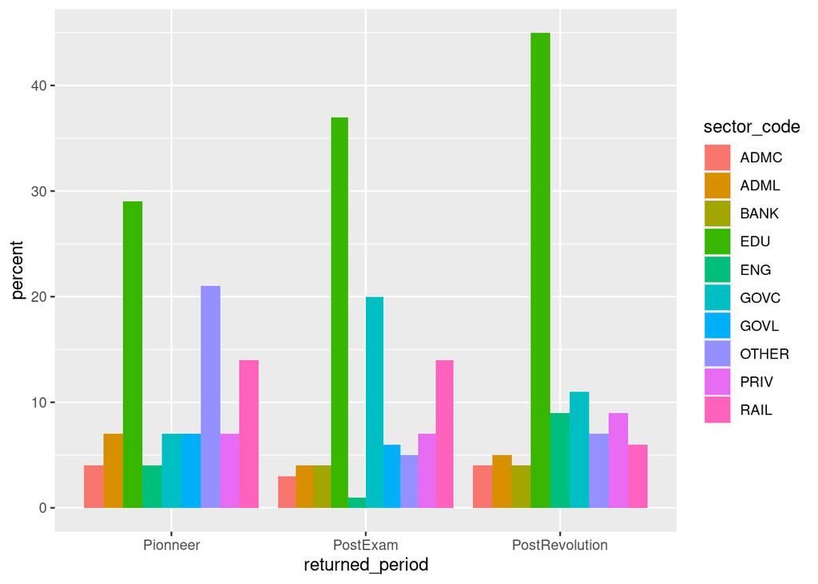

```r
ggplot(start_sector_cohort_count, aes(fill=sector_code, y=percent, x=returned_period)) +
  geom_bar(position="dodge", stat="identity")
```

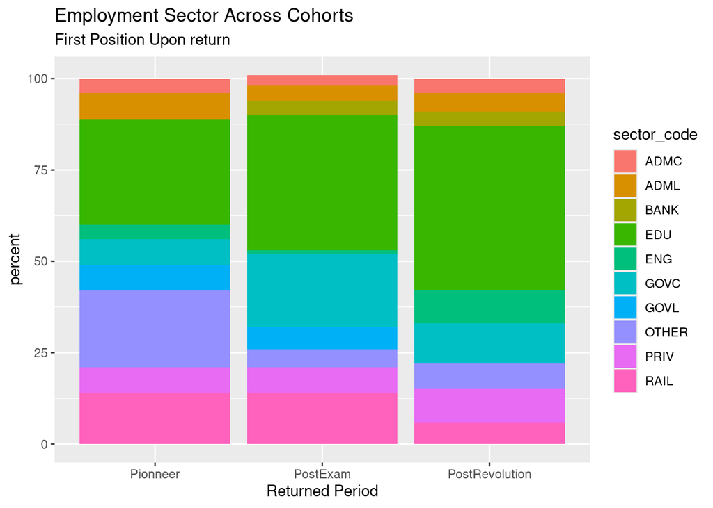

```r
ggplot(start_sector_cohort_count, aes(fill=sector_code, y=percent, x=returned_period)) +
  geom_bar(stat="identity") +
  labs(title = "Employment Sector Across Cohorts",
       subtitle = "First Position Upon return",
       x = "Returned Period")
```

```r
# Occupations by period
start_occup_cohort_count <- career_start_meta %>% group_by(returned_period, level) %>% count()
start_occup_cohort_count <- start_occup_cohort_count %>% rename(nlevel = n)
start_occup_cohort_count <- left_join(start_occup_cohort_count, period_count)
start_occup_cohort_count <- start_occup_cohort_count %>% mutate(percent = round(nlevel/n*100, 0))
```

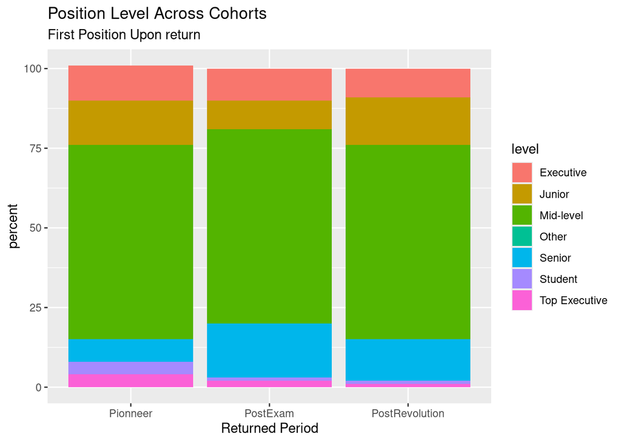

```r
ggplot(start_occup_cohort_count, aes(fill=level, y=percent, x=returned_period)) +
  geom_bar(stat="identity") +
  labs(title = "Position Level Across Cohorts",
       subtitle = "First Position Upon return",
       x = "Returned Period")
```

## Workplace

```r
start_geo_cohort_count <- career_start_meta %>% group_by(returned_period, area) %>% count()
start_geo_cohort_count <- start_geo_cohort_count %>% rename(ngeo = n)
start_geo_cohort_count <- left_join(start_geo_cohort_count, period_count)
start_geo_cohort_count <- start_geo_cohort_count %>% mutate(percent = round(ngeo/n*100, 0))
```

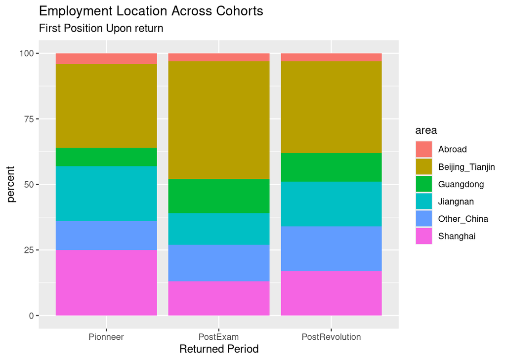

```r
ggplot(start_geo_cohort_count, aes(fill=area, y=percent, x=returned_period)) +
  geom_bar(stat="identity") +
  labs(title = "Employment Location Across Cohorts",
       subtitle = "First Position Upon return",
       x = "Returned Period")
```

# Time elapsed

In this section, we analyze how the time elapsed between the year of return and the first position varies across cohorts, depending on the return period.

```r
# Plot time elapsed by return period

start_year <- career_start_meta %>% select(DocId, year)
return_year <- main_data_all %>% select(DocId, estimated_returned_year)
return_start <- inner_join(return_year, start_year)

return_start <- return_start %>% mutate(gap = year-estimated_returned_year)
return_start <- return_start %>% na.omit()
```

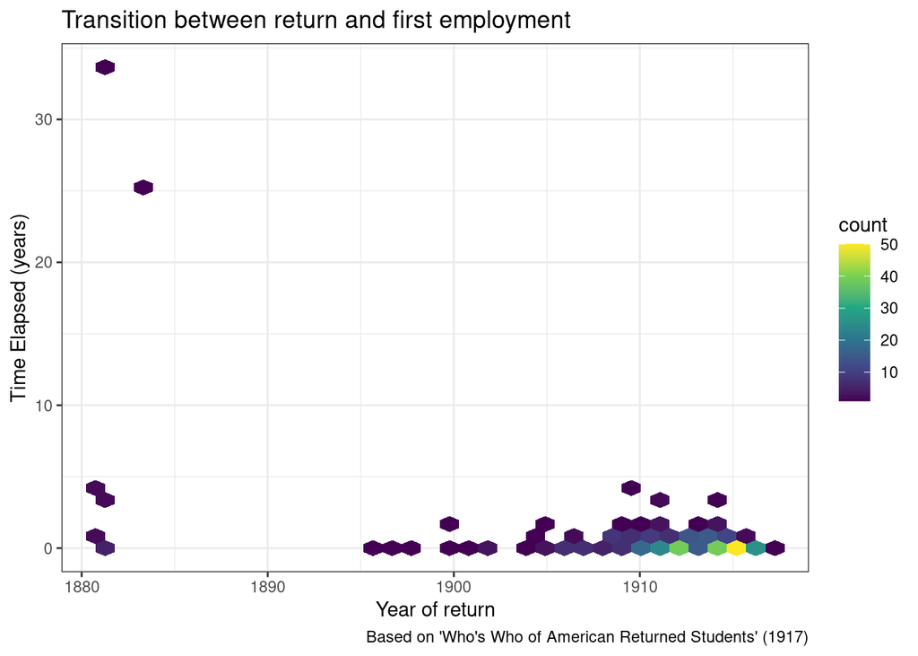

```r
ggplot(return_start, aes(x=estimated_returned_year, y=gap) ) +
  geom_hex(bins = 35) +
  scale_fill_continuous(type = "viridis") +
  theme_bw() +
  labs(title = "Transition between return and first employment",
       x = "Year of return",
       y = "Time Elapsed (years)",
       caption = "Based on 'Who's Who of American Returned Students' (1917)")
```

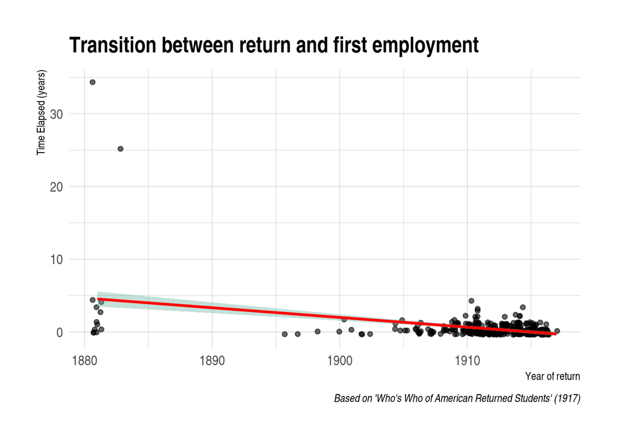

```r
library(hrbrthemes)

ggplot(return_start, aes(x=estimated_returned_year, y=gap)) +
  geom_jitter(alpha = 0.6) +
  geom_smooth(method=lm , color="red", fill="#69b3a2", se=TRUE) +
  theme_ipsum()+
  labs(
    title = "Transition between return and first employment",
    x = "Year of return",
    y = "Time Elapsed (years)",
    caption = "Based on 'Who's Who of American Returned Students' (1917)"
  )
```

# Trajectory analysis

## Did they return to their place of birth?

### Province

```r
# we observe at two levels (1) province (2) city

province_start <- career_start %>% select(DocId, province) %>% rename(target = province)
province_birth <- main_data_all %>% select(DocId, Birth_Province_eng_standard) %>% rename(source = Birth_Province_eng_standard)
province_match <- inner_join(province_birth, province_start)

# compute weight
link1 <- province_match %>%
  select(source, target) %>%
  group_by(source, target) %>%
  count() %>%
  rename(value = "n") %>% drop_na(target)

link1$same <-ifelse(link1$source==link1$target,"TRUE","FALSE")

link12 <-link1 %>% filter(value>1)

node12 <- data.frame(
  name=c(as.character(link12$source),
         as.character(link12$target)) %>% unique()
)

# create unique id for each connection
link12$IDsource <- match(link12$source, node12$name)-1
link12$IDtarget <- match(link12$target, node12$name)-1
```

```r
# Visualize
library(networkD3)

p1 <- sankeyNetwork(Links = link12, Nodes = node12,
                    Source = "IDsource", Target = "IDtarget",
                    Value = "value", NodeID = "name",
                    sinksRight=FALSE)
p1
```

[interactive chart not shown]

```r
# compare to total births

province_count <- province_match %>% group_by(source) %>% count()

link1 <- left_join(link1, province_count)
link1 <- link1 %>% mutate(percent = round(value/n*100, 2))

# Detailed list of return loops

link1 %>% filter(same == "TRUE") %>% arrange(desc(value))
```

```
## # A tibble: 12 × 6
## # Groups:   source, target [12]
##    source    target    value same      n percent
##    <chr>     <chr>     <int> <chr> <int>   <dbl>
##  1 Jiangsu   Jiangsu      57 TRUE    123   46.3
##  2 Guangdong Guangdong    26 TRUE     96   27.1
##  3 Hebei     Hebei        12 TRUE     19   63.2
##  4 Hubei     Hubei         7 TRUE     16   43.8
##  5 Jiangxi   Jiangxi       5 TRUE      6   83.3
##  6 Fujian    Fujian        4 TRUE     16   25
##  7 Zhejiang  Zhejiang      3 TRUE     34    8.82
##  8 Hunan     Hunan         2 TRUE      2  100
##  9 Sichuan   Sichuan       2 TRUE      5   40
## 10 Hawaii    Hawaii        1 TRUE      6   16.7
## 11 Hongkong  Hongkong      1 TRUE      6   16.7
## 12 Shandong  Shandong      1 TRUE      3   33.3
```

```r
link1 %>% filter(same == "TRUE") %>% arrange(desc(percent))
```

```
## # A tibble: 12 × 6
## # Groups:   source, target [12]
##    source    target    value same      n percent
##    <chr>     <chr>     <int> <chr> <int>   <dbl>
##  1 Hunan     Hunan         2 TRUE      2  100
##  2 Jiangxi   Jiangxi       5 TRUE      6   83.3
##  3 Hebei     Hebei        12 TRUE     19   63.2
##  4 Jiangsu   Jiangsu      57 TRUE    123   46.3
##  5 Hubei     Hubei         7 TRUE     16   43.8
##  6 Sichuan   Sichuan       2 TRUE      5   40
##  7 Shandong  Shandong      1 TRUE      3   33.3
##  8 Guangdong Guangdong    26 TRUE     96   27.1
##  9 Fujian    Fujian        4 TRUE     16   25
## 10 Hawaii    Hawaii        1 TRUE      6   16.7
## 11 Hongkong  Hongkong      1 TRUE      6   16.7
## 12 Zhejiang  Zhejiang      3 TRUE     34    8.82
```

```r
link1 %>% filter(same == "TRUE") %>% arrange(percent)
```

```
## # A tibble: 12 × 6
## # Groups:   source, target [12]
##    source    target    value same      n percent
##    <chr>     <chr>     <int> <chr> <int>   <dbl>
##  1 Zhejiang  Zhejiang      3 TRUE     34    8.82
##  2 Hawaii    Hawaii        1 TRUE      6   16.7
##  3 Hongkong  Hongkong      1 TRUE      6   16.7
##  4 Fujian    Fujian        4 TRUE     16   25
##  5 Guangdong Guangdong    26 TRUE     96   27.1
##  6 Shandong  Shandong      1 TRUE      3   33.3
##  7 Sichuan   Sichuan       2 TRUE      5   40
##  8 Hubei     Hubei         7 TRUE     16   43.8
##  9 Jiangsu   Jiangsu      57 TRUE    123   46.3
## 10 Hebei     Hebei        12 TRUE     19   63.2
## 11 Jiangxi   Jiangxi       5 TRUE      6   83.3
## 12 Hunan     Hunan         2 TRUE      2  100
```

### Town/City

```r
city_start <- career_start %>% select(DocId, city) %>% rename(target = city)
city_birth <- main_data_all %>% select(DocId, Birth_Location_eng_standard) %>% rename(source = Birth_Location_eng_standard)
city_match <- inner_join(city_birth, city_start)

# compute weight
link2 <- city_match %>%
  select(source, target) %>%
  group_by(source, target) %>%
  count() %>%
  rename(value = "n") %>% drop_na(target)

link2$same <-ifelse(link2$source==link2$target,"TRUE","FALSE")

link22 <-link2 %>% filter(value>1)

node22 <- data.frame(
  name=c(as.character(link22$source),
         as.character(link22$target)) %>% unique()
)

# create unique id for each connection
link22$IDsource <- match(link22$source, node22$name)-1
link22$IDtarget <- match(link22$target, node22$name)-1
```

```r
library(networkD3)

p2 <- sankeyNetwork(Links = link22, Nodes = node22,
                    Source = "IDsource", Target = "IDtarget",
                    Value = "value", NodeID = "name",
                    sinksRight=FALSE)
p2
```

[interactive chart not shown]

```r
# compare to total births
city_count <- city_match %>% group_by(source) %>% count()

link2 <- left_join(link2, city_count)
link2 <- link2 %>% mutate(percent = round(value/n*100, 2))

# Detailed list of return loops

link2 %>% filter(same == "TRUE") %>% arrange(desc(value))
```

```
## # A tibble: 14 × 6
## # Groups:   source, target [14]
##    source    target    value same      n percent
##    <chr>     <chr>     <int> <chr> <int>   <dbl>
##  1 Shanghai  Shanghai     11 TRUE     48    22.9
##  2 Guangzhou Guangzhou     9 TRUE     34    26.5
##  3 Tianjin   Tianjin       8 TRUE     15    53.3
##  4 Jiujiang  Jiujiang      4 TRUE      6    66.7
##  5 Beijing   Beijing       2 TRUE      4    50
##  6 Fuzhou    Fuzhou        2 TRUE      8    25
##  7 Nanjing   Nanjing       2 TRUE      6    33.3
##  8 Suzhou    Suzhou        2 TRUE     14    14.3
##  9 Changsha  Changsha      1 TRUE      1   100
## 10 Chongqing Chongqing     1 TRUE      2    50
## 11 Hangzhou  Hangzhou      1 TRUE      7    14.3
## 12 Hongkong  Hongkong      1 TRUE      6    16.7
## 13 Honolulu  Honolulu      1 TRUE      6    16.7
## 14 Wuchang   Wuchang       1 TRUE      2    50
```

```r
link2 %>% filter(same == "TRUE") %>% arrange(desc(percent))
```

```
## # A tibble: 14 × 6
## # Groups:   source, target [14]
##    source    target    value same      n percent
##    <chr>     <chr>     <int> <chr> <int>   <dbl>
##  1 Changsha  Changsha      1 TRUE      1   100
##  2 Jiujiang  Jiujiang      4 TRUE      6    66.7
##  3 Tianjin   Tianjin       8 TRUE     15    53.3
##  4 Beijing   Beijing       2 TRUE      4    50
##  5 Chongqing Chongqing     1 TRUE      2    50
##  6 Wuchang   Wuchang       1 TRUE      2    50
##  7 Nanjing   Nanjing       2 TRUE      6    33.3
##  8 Guangzhou Guangzhou     9 TRUE     34    26.5
##  9 Fuzhou    Fuzhou        2 TRUE      8    25
## 10 Shanghai  Shanghai     11 TRUE     48    22.9
## 11 Hongkong  Hongkong      1 TRUE      6    16.7
## 12 Honolulu  Honolulu      1 TRUE      6    16.7
## 13 Hangzhou  Hangzhou      1 TRUE      7    14.3
## 14 Suzhou    Suzhou        2 TRUE     14    14.3
```

```r
link2 %>% filter(same == "TRUE") %>% arrange(percent)
```

```
## # A tibble: 14 × 6
## # Groups:   source, target [14]
##    source    target    value same      n percent
##    <chr>     <chr>     <int> <chr> <int>   <dbl>
##  1 Hangzhou  Hangzhou      1 TRUE      7    14.3
##  2 Suzhou    Suzhou        2 TRUE     14    14.3
##  3 Hongkong  Hongkong      1 TRUE      6    16.7
##  4 Honolulu  Honolulu      1 TRUE      6    16.7
##  5 Shanghai  Shanghai     11 TRUE     48    22.9
##  6 Fuzhou    Fuzhou        2 TRUE      8    25
##  7 Guangzhou Guangzhou     9 TRUE     34    26.5
##  8 Nanjing   Nanjing       2 TRUE      6    33.3
##  9 Beijing   Beijing       2 TRUE      4    50
## 10 Chongqing Chongqing     1 TRUE      2    50
## 11 Wuchang   Wuchang       1 TRUE      2    50
## 12 Tianjin   Tianjin       8 TRUE     15    53.3
## 13 Jiujiang  Jiujiang      4 TRUE      6    66.7
## 14 Changsha  Changsha      1 TRUE      1   100
```

## Did they return to teach where they were educated?

```r
# Select relevant data

edu_start <- career_start %>% filter(sector_code == "EDU") %>% select(DocId, Institution) %>% rename(Start = Institution)
china_edu <- edu_china %>% rename(education = Institution)
edu_to_start <- left_join(china_edu, edu_start)

# Build a sankey diagram

edu_to_start_network <- edu_to_start %>% distinct(DocId, education, Start) %>%
  select(education, Start) %>% rename(source = education, target = Start)

edu_to_start_network <-  edu_to_start_network %>% mutate(source = str_replace_all(source, "Foochow", "Fuzhou"))

# Remove NA and compute weight
link3 <- edu_to_start_network %>%
  group_by(source, target) %>%
  count() %>%
  rename(value = "n") %>% drop_na(target)

link32 <-link3 %>% filter(value>1)

# Create node list from edge list ; the node list contains every entity involved in the flow

node3 <- data.frame(
  name=c(as.character(link32$source),
         as.character(link32$target)) %>% unique()
)

# Create unique id for each connection
link32$IDsource <- match(link32$source, node3$name)-1
link32$IDtarget <- match(link32$target, node3$name)-1
```

```r
# Visualize the strongest flows

library(networkD3)

p3 <- sankeyNetwork(Links = link32, Nodes = node3,
                    Source = "IDsource", Target = "IDtarget",
                    Value = "value", NodeID = "name",
                    sinksRight=FALSE)
p3
```

[interactive chart not shown]

```r
# save the widget (optional)
# library(htmlwidgets)
# saveWidget(p1, file=paste0( getwd(), "~/Media/sankeys/edu_start.html"))
```

```r
# Detailed list of return loops

link3$same <-ifelse(link3$source==link3$target,"TRUE","FALSE")

link3 %>% filter(same == "TRUE") %>% arrange(desc(value))
```

```
## # A tibble: 12 × 4
## # Groups:   source, target [12]
##    source                         target                         value same
##    <chr>                          <chr>                          <int> <chr>
##  1 Canton Christian College       Canton Christian College           4 TRUE
##  2 Boone University               Boone University                   2 TRUE
##  3 Peking Government University   Peking Government University       2 TRUE
##  4 William Nast College           William Nast College               2 TRUE
##  5 Anglo-Chinese College (Fuzhou) Anglo-Chinese College (Fuzhou)     1 TRUE
##  6 McTyeire School                McTyeire School                    1 TRUE
##  7 Nanyang College                Nanyang College                    1 TRUE
##  8 Peiyang University             Peiyang University                 1 TRUE
##  9 Peking Methodist University    Peking Methodist University        1 TRUE
## 10 St. John's University          St. John's University              1 TRUE
## 11 Tientsin Industrial College    Tientsin Industrial College        1 TRUE
## 12 University of Nanking          University of Nanking              1 TRUE
```